# Demonstrating Genetic Regulation in SignalGP - Analysis - Directional Signal Regulation Graphs vs. Repeated Signal Regulation Graphs

## Setup

Load required libraries/packages.

```r
library(ggplot2)  # (Wickham, 2009)
library(tidyr)    # (Wickham and Henry, 2018)
library(dplyr)    # (Wickham et al., 2018)
library(cowplot)  # (Wilke, 2018)
library(viridis)  # (Garnier, 2018)
library(reshape2)
library(RColorBrewer)
library(igraph)
library(patchwork)
```

Configure a few global variables.

```r
theme_set(theme_cowplot())
alpha <- 0.05
correction_method <- "bonferroni"
```

Load repeated signal task data.

```r
alt_sig_org_data_loc <- "../data/reg-graph-comps/alt-sig/max_fit_orgs.csv"
alt_sig_org_data <- read.csv(alt_sig_org_data_loc, na.strings="NONE")
alt_sig_org_data <- subset(alt_sig_org_data, select = -c(program))

# Specify factors.
alt_sig_org_data$matchbin_thresh <- factor(alt_sig_org_data$matchbin_thresh,
                                           levels=c(0, 25, 50, 75))
alt_sig_org_data$NUM_SIGNAL_RESPONSES <- factor(alt_sig_org_data$NUM_SIGNAL_RESPONSES,
                                                levels=c(2, 4, 8, 16, 32))
alt_sig_org_data$NUM_ENV_CYCLES <- factor(alt_sig_org_data$NUM_ENV_CYCLES,
                                          levels=c(2, 4, 8, 16, 32))
alt_sig_org_data$TAG_LEN <- factor(alt_sig_org_data$TAG_LEN,
                                   levels=c(32, 64, 128))
# Define function to summarize regulation/memory configurations.
get_con <- function(reg, mem) {
  if (reg == "0" && mem == "0") {
    return("none")
  } else if (reg == "0" && mem=="1") {
    return("memory")
  } else if (reg=="1" && mem=="0") {
    return("regulation")
  } else if (reg=="1" && mem=="1") {
    return("both")
  } else {
    return("UNKNOWN")
  }
}
# Specify experimental condition for each datum.
alt_sig_org_data$condition <- mapply(get_con,
                                     alt_sig_org_data$USE_FUNC_REGULATION,
                                     alt_sig_org_data$USE_GLOBAL_MEMORY)
alt_sig_org_data$condition <- factor(alt_sig_org_data$condition,
                                     levels=c("regulation", "memory", "none", "both"))

# Does this program rely on a stochastic strategy?
alt_sig_org_data$stochastic <- 1 - alt_sig_org_data$consistent

alt_sig_network_data_loc <- "../data/reg-graph-comps/alt-sig/reg_graphs_summary.csv"
alt_sig_network_data <- read.csv(alt_sig_network_data_loc, na.strings="NA")
```

Load directional signal task data.

```r
dir_sig_org_data_loc <- "../data/reg-graph-comps/dir-sig/max_fit_orgs.csv"
dir_sig_org_data <- read.csv(dir_sig_org_data_loc, na.strings="NONE")
dir_sig_org_data <- subset(dir_sig_org_data, select = -c(program))

# Specify factors.
dir_sig_org_data$matchbin_thresh <- factor(dir_sig_org_data$matchbin_thresh,
                                           levels=c(0, 25, 50, 75))
dir_sig_org_data$NUM_ENV_UPDATES <- factor(dir_sig_org_data$NUM_ENV_UPDATES,
                                           levels=c(2, 4, 8, 16, 32))
dir_sig_org_data$NUM_ENV_STATES <- factor(dir_sig_org_data$NUM_ENV_STATES,
                                          levels=c(2, 4, 8, 16, 32))
dir_sig_org_data$TAG_LEN <- factor(dir_sig_org_data$TAG_LEN,
                                   levels=c(32, 64, 128))
dir_sig_org_data$MUT_RATE__FUNC_DUP <- factor(dir_sig_org_data$MUT_RATE__FUNC_DUP,
                                              levels=c("0.01", "0.05", "0.1"))

# Define function to summarize regulation/memory configurations.
get_con <- function(reg, mem) {
  if (reg == "0" && mem == "0") {
    return("none")
  } else if (reg == "0" && mem=="1") {
    return("memory")
  } else if (reg=="1" && mem=="0") {
    return("regulation")
  } else if (reg=="1" && mem=="1") {
    return("both")
  } else {
    return("UNKNOWN")
  }
}
# Specify experimental condition for each datum.
dir_sig_org_data$condition <- mapply(get_con,
                                     dir_sig_org_data$USE_FUNC_REGULATION,
                                     dir_sig_org_data$USE_GLOBAL_MEMORY)
dir_sig_org_data$condition <- factor(dir_sig_org_data$condition,
                                     levels=c("regulation", "memory", "none", "both"))

dir_sig_network_data_loc <- "../data/reg-graph-comps/dir-sig/reg_graphs_summary.csv"
dir_sig_network_data <- read.csv(dir_sig_network_data_loc, na.strings="NA")
dir_sig_network_data$test_id <- factor(dir_sig_network_data$test_id,
                                       levels(factor(dir_sig_network_data$test_id)))
```

## How many solutions evolved on each task?

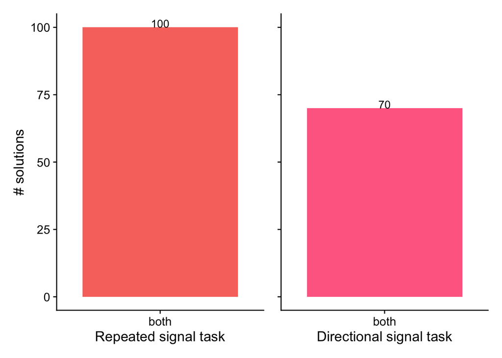

```r
sol_alt_sigs <- filter(alt_sig_org_data, solution=="1")
alt_sig_sol_plot <- ggplot(sol_alt_sigs, aes(x=condition, fill=condition)) +
  geom_bar() +
  geom_text(stat="count", aes(label=..count..), position=position_dodge(0.9), vjust=0) +
  xlab("Repeated signal task") +
  scale_y_continuous(name="# solutions",
                     limits=c(0, 100)) +
  theme(legend.position="none")

sol_dir_sigs <- filter(dir_sig_org_data, solution=="1")
dir_sig_sol_plot <- ggplot(sol_dir_sigs, aes(x=condition, fill=condition)) +
  geom_bar() +
  geom_text(stat="count", aes(label=..count..), position=position_dodge(0.9), vjust=0) +
  xlab("Directional signal task") +
  scale_y_continuous(name="# solutions",
                   limits=c(0, 100)) +
  scale_fill_discrete(direction=-1)+
  theme(legend.position = "none",
        axis.text.y=element_blank(),
        axis.title.y=element_blank())

alt_sig_sol_plot | dir_sig_sol_plot
```

## Networks?

Extract regulatory networks of solutions.

```r
# Extract successful runs (solution) of given mutation rate.
dir_sig_solutions <- filter(dir_sig_org_data, solution=="1")
# Isolate networks of successful runs.
dir_sig_sol_networks <- filter(dir_sig_network_data,
                               run_id %in% dir_sig_solutions$SEED)
dir_sig_sol_networks$exp <- "Directional Signal"

alt_sig_solutions <- filter(alt_sig_org_data, solution=="1")
alt_sig_sol_networks <- filter(alt_sig_network_data, run_id %in% alt_sig_solutions$SEED)
alt_sig_sol_networks$exp <- "Repeated Signal"

all_sol_networks <- rbind(alt_sig_sol_networks, dir_sig_sol_networks)
```

### Visualizing LOTS of simple graph metrics

*simple, except for flow hierarchy, graph density, and reciprocity, which are less simple

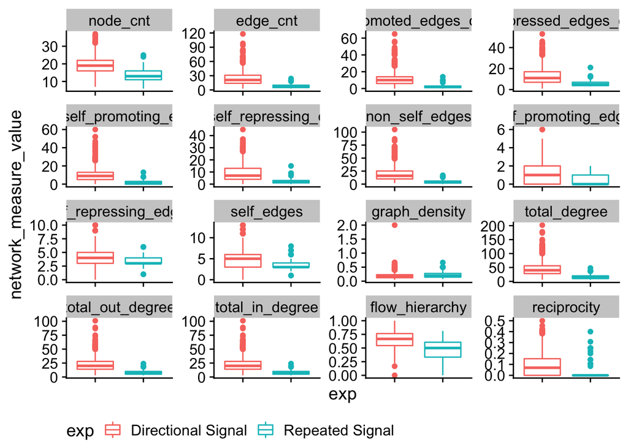

```r
# Melt all of the network metrics together, allowing us to facet over them.
network_measures_melted <- melt(all_sol_networks,
                                variable.name = "network_measure",
                                value.name = "network_measure_value",
                                measure.vars=c("node_cnt",
                                               "edge_cnt",
                                               "promoted_edges_cnt",
                                               "repressed_edges_cnt",
                                               "non_self_promoting_edges",
                                               "non_self_repressing_edges",
                                               "non_self_edges",
                                               "self_promoting_edges",
                                               "self_repressing_edges",
                                               "self_edges",
                                               "graph_density",
                                               "total_degree",
                                               "total_out_degree",
                                               "total_in_degree",
                                               "flow_hierarchy",
                                               "reciprocity"))

ggplot(network_measures_melted, aes(x=exp, y=network_measure_value, color=exp)) +
  geom_boxplot() +
  facet_wrap(~network_measure, scales="free") +
  theme(legend.position = "bottom", axis.text.x=element_blank()) +
  ggsave("./imgs/network_measures_all.pdf", width=10, height=10)
```

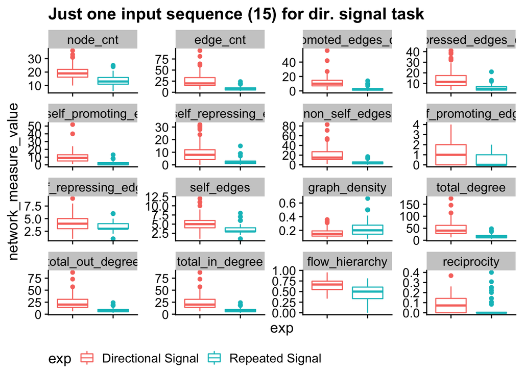

```r
# Plot only test_id
ds_test_id <- 15
ggplot(filter(network_measures_melted,
              exp=="Repeated Signal" |
              (exp=="Directional Signal" & test_id==ds_test_id)),
       aes(x=exp, y=network_measure_value, color=exp)) +
  geom_boxplot() +
  facet_wrap(~network_measure, scales="free") +
  theme(legend.position = "bottom", axis.text.x=element_blank()) +
  ggtitle(paste("Just one input sequence (", ds_test_id ,") for dir. signal task", sep="")) +
  ggsave("./imgs/network_measures_all_single_test.pdf", width=10, height=10)
```

Okay, from all of this our intuition (see other analysis files) that networks that solve the directional signal are bigger (use more functions) and have more interaction among functions (regulatory relationships). Network vertex count and edge count are sufficient to tell this story.

[figure not shown]

```r
## --- All environment sequences ---
# node_cnt
plot_nodes <-
ggplot(all_sol_networks, aes(x=exp, y=node_cnt, color=exp)) +
  geom_boxplot() +
  ylab("Vertices") +
  scale_x_discrete(name="Task",
                 limits=c("Directional Signal", "Repeated Signal"),
                 labels=c("D", "R")) +
  ylim(0, 120) +
  theme(legend.position = "none")
# edge_cnt
plot_edges <-
ggplot(all_sol_networks, aes(x=exp, y=edge_cnt, color=exp)) +
  geom_boxplot() +
  ylab("Edges") +
  scale_x_discrete(name="Task",
                   limits=c("Directional Signal", "Repeated Signal"),
                   labels=c("D", "R")) +
  ylim(0, 120) +
  theme(legend.position = "none")
plots <- plot_nodes | plot_edges
plots
```

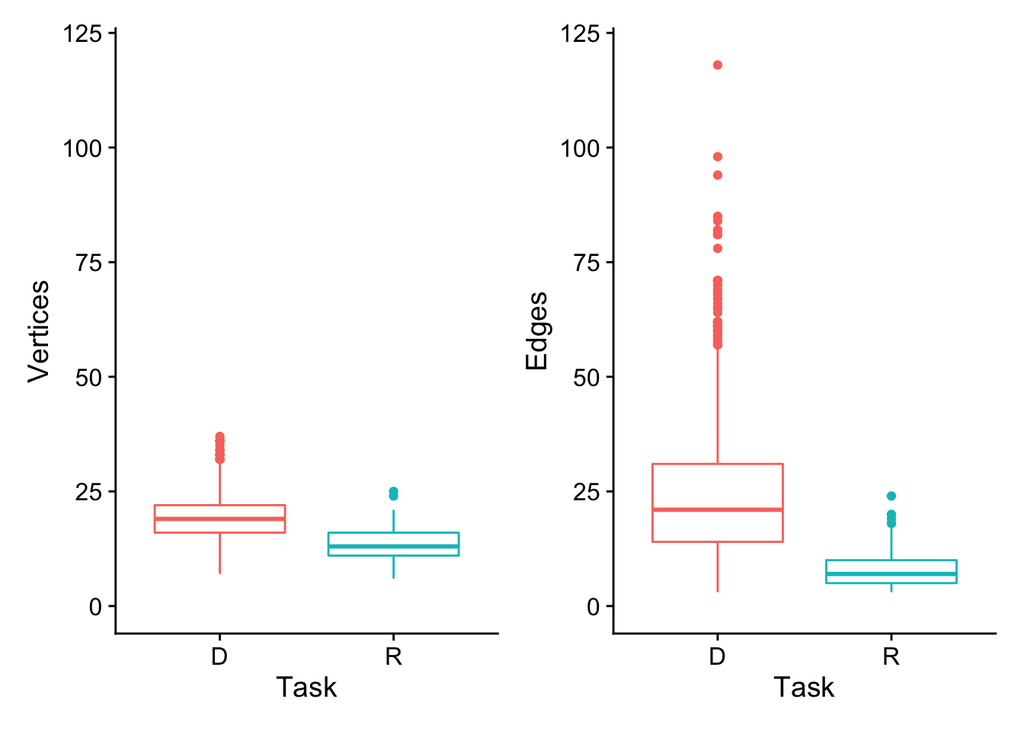

```r
plots + ggsave("./imgs/reg_networks_vertices_and_edges.pdf", width=4, height=3)
```

Let’s compare node counts and edge counts (wilcoxon rank sum test)

```r
wilcox.test(formula=node_cnt ~ exp, data=all_sol_networks, conf.int=TRUE)
```

```
##
##  Wilcoxon rank sum test with continuity correction
##
## data:  node_cnt by exp
## W = 93759, p-value < 2.2e-16
## alternative hypothesis: true location shift is not equal to 0
## 95 percent confidence interval:
##  4.999946 6.000031
## sample estimates:
## difference in location
##                5.00003
```

```r
ds_test_id=15 # all 'right' environment shifts
wilcox.test(formula=node_cnt ~ exp, data=filter(all_sol_networks,
                                                exp=="Repeated Signal" |
                                                  (exp=="Directional Signal" & test_id==ds_test_id)))
```

```
##
##  Wilcoxon rank sum test with continuity correction
##
## data:  node_cnt by exp
## W = 6147.5, p-value < 2.2e-16
## alternative hypothesis: true location shift is not equal to 0
```

```r
wilcox.test(formula=edge_cnt ~ exp, data=all_sol_networks)
```

```
##
##  Wilcoxon rank sum test with continuity correction
##
## data:  edge_cnt by exp
## W = 102751, p-value < 2.2e-16
## alternative hypothesis: true location shift is not equal to 0
```

```r
wilcox.test(formula=edge_cnt ~ exp, data=filter(all_sol_networks,
                                                exp=="Repeated Signal" |
                                                  (exp=="Directional Signal" & test_id==ds_test_id)))
```

```
##
##  Wilcoxon rank sum test with continuity correction
##
## data:  edge_cnt by exp
## W = 6514, p-value < 2.2e-16
## alternative hypothesis: true location shift is not equal to 0
```

Yes, differences in number of vertices and the number of edges between networks evolved to solve the repeated signal task versus networks evolved to solve the directional signal task are significant.

## Are evolved solution relying on up-regulation, down-regulation, or both?

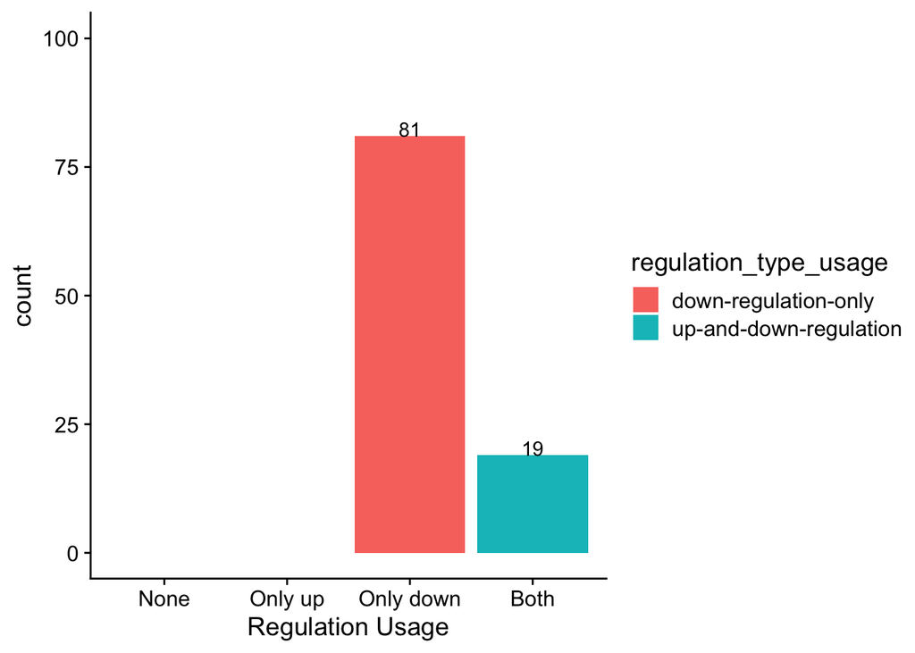

```r
alt_sig_org_sols <- filter(alt_sig_org_data, solution=="1")
# How many rely only on down-regulation, only on up-regulation, and on both?
get_reg_relies_on <- function(uses_down, uses_up) {
  if        (uses_down == "0" && uses_up == "0") {
    return("neither")
  } else if (uses_down == "0" && uses_up == "1") {
    return("up-regulation-only")
  } else if (uses_down == "1" && uses_up == "0") {
    return("down-regulation-only")
  } else if (uses_down == "1" && uses_up == "1") {
    return("up-and-down-regulation")
  } else {
    return("UNKNOWN")
  }
}
alt_sig_org_sols$regulation_type_usage <- mapply(get_reg_relies_on,
                                                 alt_sig_org_sols$relies_on_down_reg,
                                                 alt_sig_org_sols$relies_on_up_reg)
alt_sig_org_sols$regulation_type_usage <- factor(alt_sig_org_sols$regulation_type_usage,
                                                 levels=c("neither", "up-regulation-only", "down-regulation-only", "up-and-down-regulation"))

ggplot(alt_sig_org_sols, aes(x=regulation_type_usage, fill=regulation_type_usage)) +
  geom_bar() +
  ylim(0, 100) +
  scale_x_discrete(name="Regulation Usage",
                   limits=c("neither", "up-regulation-only", "down-regulation-only", "up-and-down-regulation"),
                   labels=c("None", "Only up", "Only down", "Both")) +
  geom_text(stat="count", aes(label=..count..), position=position_dodge(0.9), vjust=0)
```

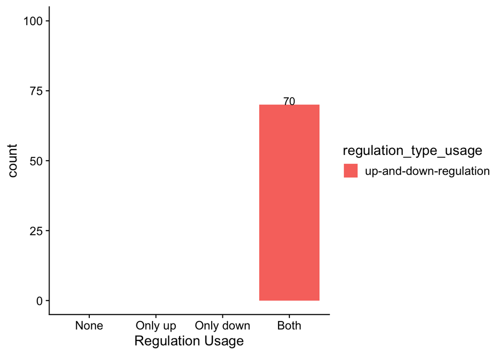

```r
dir_sig_org_sols <- filter(dir_sig_org_data, solution=="1")

dir_sig_org_sols$regulation_type_usage <- mapply(get_reg_relies_on,
                                                 dir_sig_org_sols$relies_on_down_reg,
                                                 dir_sig_org_sols$relies_on_up_reg)
dir_sig_org_sols$regulation_type_usage <- factor(dir_sig_org_sols$regulation_type_usage,
                                                 levels=c("neither", "up-regulation-only", "down-regulation-only", "up-and-down-regulation"))

ggplot(dir_sig_org_sols, aes(x=regulation_type_usage, fill=regulation_type_usage)) +
  geom_bar() +
  ylim(0, 100) +
  scale_x_discrete(name="Regulation Usage",
                   limits=c("neither", "up-regulation-only", "down-regulation-only", "up-and-down-regulation"),
                   labels=c("None", "Only up", "Only down", "Both")) +
  geom_text(stat="count", aes(label=..count..), position=position_dodge(0.9), vjust=0)
```

### How many up-regulation and down-regulation connections exist in regulatory networks?

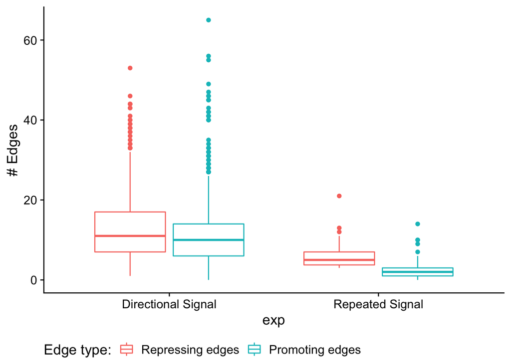

```r
melted <- melt(all_sol_networks,
               variable.name = "reg_edge_type",
               value.name = "reg_edge_cnt",
               measure.vars=c("repressed_edges_cnt", "promoted_edges_cnt"))
ggplot(melted, aes(x=exp, y=reg_edge_cnt, color=reg_edge_type)) +
  geom_boxplot() +
  ylab("# Edges") +
  scale_color_discrete(name="Edge type:",
                     limits=c("repressed_edges_cnt", "promoted_edges_cnt"),
                     labels=c("Repressing edges", "Promoting edges")) +
  theme(legend.position = "bottom")
```

Compare number of up/down-regulation edges in the regulatory networks that solve the repeated signal solutions task.

```r
wilcox.test(formula=reg_edge_cnt ~ reg_edge_type, data=filter(melted, exp=="Repeated Signal"))
```

```
##
##  Wilcoxon rank sum test with continuity correction
##
## data:  reg_edge_cnt by reg_edge_type
## W = 8645.5, p-value < 2.2e-16
## alternative hypothesis: true location shift is not equal to 0
```

Compare number of up/down-regulation edges in the regulatory networks that solve the directional signal task (for each possible environment sequence).

```r
test_ids <- levels(factor( filter(melted, exp=="Directional Signal")$test_id ) )
for (id in test_ids) {
 print(paste("Compare on test sequence", id))
 tst <- wilcox.test(formula=reg_edge_cnt ~ reg_edge_type,
             data=filter(melted, exp=="Directional Signal" & test_id==id))
 print(tst)
}
```

```
## [1] "Compare on test sequence 0"
##
##  Wilcoxon rank sum test with continuity correction
##
## data:  reg_edge_cnt by reg_edge_type
## W = 2804.5, p-value = 0.1394
## alternative hypothesis: true location shift is not equal to 0
##
## [1] "Compare on test sequence 1"
##
##  Wilcoxon rank sum test with continuity correction
##
## data:  reg_edge_cnt by reg_edge_type
## W = 2979.5, p-value = 0.02726
## alternative hypothesis: true location shift is not equal to 0
##
## [1] "Compare on test sequence 10"
##
##  Wilcoxon rank sum test with continuity correction
##
## data:  reg_edge_cnt by reg_edge_type
## W = 2521, p-value = 0.7682
## alternative hypothesis: true location shift is not equal to 0
##
## [1] "Compare on test sequence 11"
##
##  Wilcoxon rank sum test with continuity correction
##
## data:  reg_edge_cnt by reg_edge_type
## W = 3031, p-value = 0.01534
## alternative hypothesis: true location shift is not equal to 0
##
## [1] "Compare on test sequence 12"
##
##  Wilcoxon rank sum test with continuity correction
##
## data:  reg_edge_cnt by reg_edge_type
## W = 2949, p-value = 0.03751
## alternative hypothesis: true location shift is not equal to 0
##
```

[output cut: 72 more lines]

```
## [1] "Compare on test sequence 8"
##
##  Wilcoxon rank sum test with continuity correction
##
## data:  reg_edge_cnt by reg_edge_type
## W = 3052.5, p-value = 0.01199
## alternative hypothesis: true location shift is not equal to 0
##
## [1] "Compare on test sequence 9"
##
##  Wilcoxon rank sum test with continuity correction
##
## data:  reg_edge_cnt by reg_edge_type
## W = 2607.5, p-value = 0.512
## alternative hypothesis: true location shift is not equal to 0
```